# Ibex: deep autoencoders for single-cell B-cell receptor analysis

3 October 2023

# Summary

B cells are critical for adaptive immunity and are governed by the recognition of an antigen by the B cell receptor (BCR), a process that drives a coordinated series of signaling events and modulation of various transcriptional programs. Single-cell RNA sequencing with paired BCR profiling could offer insights into numerous physiological and pathological processes. However, unlike the plethora of single-cell RNA analysis pipelines, computational tools that utilize single-cell BCR sequences for further analyses are not yet well developed. Here we report Ibex, which vectorizes the amino acid sequence of the complementarity-determining region 3 (CDR3) of the immunoglobulin heavy and light chains, allowing for unbiased dimensional reduction of B cells using their BCR repertoire. Ibex is implemented as an R package with integration into both the Seurat and Single-Cell Experiment framework, enabling the incorporation of this new analytic tool into many single-cell sequencing analytic workflows and multimodal experiments.

[figure not shown]

# Statement of need

Single-cell sequencing has become a mainstay in immunology. In addition to enabling the characterization of various immune populations and their transcriptional profiles, single-cell sequencing technologies allow for the pairing of transcriptomic and clonotypic data providing insight into the complexities of the adaptive immune response. In the context of lymphocytes, the immune response is regulated by antigen recognition at the site of the adaptive immune receptor. In B cells, somatic recombination genes determine the BCR sequence at heavy and light chain loci (Schatz and Ji 2011) and in the germinal center via somatic hypermutation (Odegard and Schatz 2006). This process collectively produces groups of “clonal lineages” sequences that are generally used as categorical data in single-cell analysis.

Several tools have been put forth to integrate single-cell transcriptomic and T-cell receptor sequences, such as `CoNGA` (Schattgen et al. 2022), `TESSA` (Zhang et al. 2021), and `mvTCR` (Drost et al. 2022). The latter two tools leverage neural networks to generate a latent representation of the CDR3 sequence. The power of this approach has been shown in cancer detection (Beshnova et al. 2020) and in predicting responses to immunotherapy (Sidhom et al. 2022). Recent deep-learning approaches have shown promise in optimizing antibody selection (Mason et al., 2021). Other groups propose the potential of using natural language processing to better understand the linguistics of immunoglobulins (Ig) and improve *in silico* development (Vu et al. 2022; Ostrovsky-Berman et al. 2021). However, except the recent Benisse python package (Zhang et al. 2022), tools for integrating multimodal single-cell sequencing data with BCR sequences are lacking and nonexistent for the R environment.

Using deep autoencoder models, we developed an intuitive tool to encode single-cell BCR light and heavy chain sequences. For each chain, the CDR3 sequence is directly converted to a format for one-hot autoencoding or first converted into an amino acid property matrix, such as Atchley factors (Atchley et al. 2005) or Kidera factors (Kidera et al. 1985). This latter conversion has been applied to TCR strategies, such in motif-based repertoire profiling via support vector machines (Thomas et al. 2014). The respective chain- and approach-specific model is then applied to the resulting transformation to produce encoded numerical vectors. With the Ibex package, the encoded numerical vectors can be incorporated into single-cell objects and used directly for dimensional reduction or multimodal integration. This provides an uncomplicated and adaptable approach for the incorporation of BCR sequences to the analysis of single-cell B-cell data. In addition, Ibex is compatible with our previous `scRepertoire` R package (Borcherding, Bormann, and Kraus 2020), enabling users to easily attach adaptive immune receptor sequences to single-cell objects.

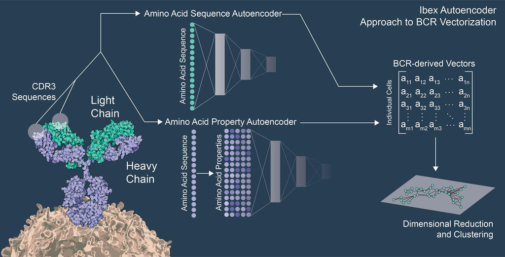

**Figure 2:** Schematic diagram of sequence encoding of the complementarity-determining region 3 (CDR3) amino acid sequences performed by Ibex.

# Underlying Models and Training

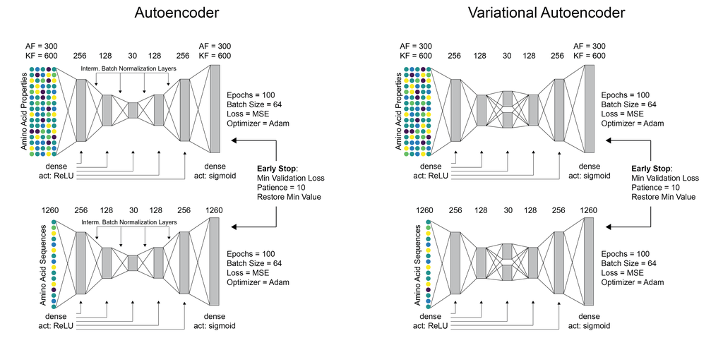

# Minimal Example

To install `Ibex` use:

```r
devtools::install_github("ncborcherding/Ibex")
```

Using Ibex, we can investigate single-cell data to combine gene expression, protein quantifications, and BCR sequences into a single representation. To demonstrate the application of Ibex, we investigated single-cell peripheral blood B cells in COVID-19-associated multisystem inflammatory syndrome (Ramaswamy et al. 2021).

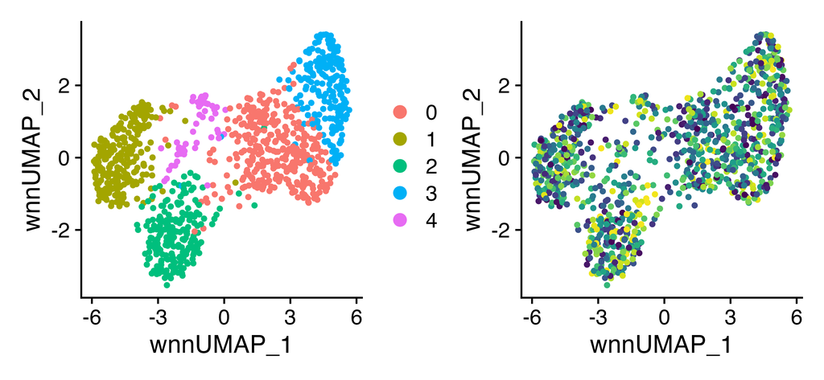

**Figure 4:** Uniform Manifold Approximation and Projection of the trimodal (RNA + Protein + BCR) numerical vectors visualizing the clusters (left panel) and unique CDR3 sequences (right panel).

```r
library(Ibex)
library(Seurat)
library(ggplot2)
library(patchwork)

#Loading the example data
SeuratObj <- readRDS(url("https://www.borch.dev/uploads/data/Ibex_FullExample.rds"))

#Running Ibex on the Heavy Chain
SeuratObj <- runIbex(SeuratObj,
                     chains = "Heavy",
                     encoder.input = "KF",
                     reduction.name = "ibex.KF")

#Combining RNA, Protein, and Ibex vectors with WNN
SeuratObj <- FindMultiModalNeighbors(
                    SeuratObj,
                    reduction.list = list("pca", "apca", "ibex.KF"),
                    dims.list = list(1:30, 1:20, 1:30),
                    modality.weight.name = "RNA.weight")

#Dimensional Reduction for WNN
SeuratObj <- RunUMAP(SeuratObj,
                     nn.name = "weighted.nn",
                     reduction.name = "wnn.umap",
                     reduction.key = "wnnUMAP_")
#Clustering the WNN
SeuratObj <- FindClusters(SeuratObj,
                          graph.name = "wsnn",
                          resolution = 0.6,
                          algorithm = 3, verbose = FALSE)

#Visualizing the trimodal-based reductions
plot3 <- DimPlot(SeuratObj, reduction = "wnn.umap")
plot4 <- DimPlot(SeuratObj, reduction = "wnn.umap", group.by = "CTaa") +
  scale_color_viridis(discrete = TRUE) +
  theme(plot.title = element.blank()) +
  NoLegend()

plot1 + plot2
```

# Acknowledgements

This work was supported by the National Institutes of Health (NIH) Common Fund via the NIH Director’s Early Independence Award (DP5 OD028125) to J.R.B and Departmental Funding from the Department of Pathology and Immunology at Washington University. The authors have no conflicts of interest related to the contents of this work.

# References

Atchley, William R., Jieping Zhao, Andrew D. Fernandes, and Tanja Drüke. 2005. “Solving the Protein Sequence Metric Problem.” *Proceedings of the National Academy of Sciences* 102 (18): 6395–6400. https://doi.org/10.1073/pnas.0408677102.

Beshnova, Daria, Jianfeng Ye, Oreoluwa Onabolu, Benjamin Moon, Wenxin Zheng, Yang-Xin Fu, James Brugarolas, Jayanthi Lea, and Bo Li. 2020. “De Novo Prediction of Cancer-Associated T Cell Receptors for Noninvasive Cancer Detection.” *Science Translational Medicine* 12 (557): eaaz3738. https://doi.org/10.1126/scitranslmed.aaz3738.

Borcherding, Nicholas, Nicholas L. Bormann, and Gloria Kraus. 2020. “scRepertoire: An R-Based Toolkit for Single-Cell Immune Receptor Analysis.” *F1000Research* 9 (June): 47. https://doi.org/10.12688/f1000research.22139.2.

Drost, Felix, Yang An, Lisa M. Dratva, Rik GH Lindeboom, Muzlifah Haniffa, Sarah A. Teichmann, Fabian Theis, Mohammad Lotfollahi, and Benjamin Schubert. 2022. “Integrating T-Cell Receptor and Transcriptome for Large-Scale Single-Cell Immune Profiling Analysis.” bioRxiv. https://doi.org/10.1101/2021.06.24.449733.

Kidera, Akinori, Yasuo Konishi, Masahito Oka, Tatsuo Ooi, and Harold A. Scheraga. 1985. “Statistical Analysis of the Physical Properties of the 20 Naturally Occurring Amino Acids.” *Journal of Protein Chemistry* 4 (1): 23–55. https://doi.org/10.1007/BF01025492.

Odegard, Valerie H., and David G. Schatz. 2006. “Targeting of Somatic Hypermutation.” *Nature Reviews Immunology* 6 (8): 573–83. https://doi.org/10.1038/nri1896.

Ostrovsky-Berman, Miri, Boaz Frankel, Pazit Polak, and Gur Yaari. 2021. “Immune2vec: Embedding B/T Cell Receptor Sequences in ℝN Using Natural Language Processing.” *Frontiers in Immunology* 12. https://www.frontiersin.org/articles/10.3389/fimmu.2021.680687.

Ramaswamy, Anjali, Nina N. Brodsky, Tomokazu S. Sumida, Michela Comi, Hiromitsu Asashima, Kenneth B. Hoehn, Ningshan Li, Yunqing Liu, Aagam Shah, and Neal G. Ravindra. 2021. “Immune Dysregulation and Autoreactivity Correlate with Disease Severity in SARS-CoV-2-Associated Multisystem Inflammatory Syndrome in Children.” *Immunity* 54 (5): 1083–95. https://www.cell.com/immunity/pdf/S1074-7613(21)00165-5.pdf.

Schattgen, Stefan A., Kate Guion, Jeremy Chase Crawford, Aisha Souquette, Alvaro Martinez Barrio, Michael J. T. Stubbington, Paul G. Thomas, and Philip Bradley. 2022. “Integrating T Cell Receptor Sequences and Transcriptional Profiles by Clonotype Neighbor Graph Analysis (CoNGA).” *Nature Biotechnology* 40 (1): 54–63. https://doi.org/10.1038/s41587-021-00989-2.

Schatz, David G., and Yanhong Ji. 2011. “Recombination Centres and the Orchestration of V(D)J Recombination.” *Nature Reviews Immunology* 11 (4): 251–63. https://doi.org/10.1038/nri2941.

Sidhom, John-William, Giacomo Oliveira, Petra Ross-MacDonald, Megan Wind-Rotolo, Catherine J. Wu, Drew M. Pardoll, and Alexander S. Baras. 2022. “Deep Learning Reveals Predictive Sequence Concepts Within Immune Repertoires to Immunotherapy.” *Science Advances* 8 (37): eabq5089. https://doi.org/10.1126/sciadv.abq5089.

Thomas, Niclas, Katharine Best, Mattia Cinelli, Shlomit Reich-Zeliger, Hilah Gal, Eric Shifrut, Asaf Madi, Nir Friedman, John Shawe-Taylor, and Benny Chain. 2014. “Tracking Global Changes Induced in the CD4 T-Cell Receptor Repertoire by Immunization with a Complex Antigen Using Short Stretches of CDR3 Protein Sequence.” *Bioinformatics* 30 (22): 3181–88. https://doi.org/10.1093/bioinformatics/btu523.

Vu, Mai Ha, Philippe A. Robert, Rahmad Akbar, Bartlomiej Swiatczak, Geir Kjetil Sandve, Dag Trygve Truslew Haug, and Victor Greiff. 2022. “ImmunoLingo: Linguistics-Based Formalization of the Antibody Language.” arXiv. https://doi.org/10.48550/arXiv.2209.12635.

Zhang, Ze, Woo Yong Chang, Kaiwen Wang, Yuqiu Yang, Xinlei Wang, Chen Yao, Tuoqi Wu, Li Wang, and Tao Wang. 2022. “Interpreting the B-Cell Receptor Repertoire with Single-Cell Gene Expression Using Benisse.” *Nature Machine Intelligence* 4 (6): 596–604. https://doi.org/10.1038/s42256-022-00492-6.

Zhang, Ze, Danyi Xiong, Xinlei Wang, Hongyu Liu, and Tao Wang. 2021. “Mapping the Functional Landscape of T Cell Receptor Repertoires by Single-T Cell Transcriptomics.” *Nature Methods* 18 (1): 92–99. https://doi.org/10.1038/s41592-020-01020-3.